# BAZY DANYCH, SEMESTR LETNI 2024/2025

## Projekt - analiza danych

##### Arkadiusz Kijaczek, Bartosz Łuksza, Hubert Zawerbny, Mateusz Dziamba, Wiktor Jasiński

# 1. Analiza rentowności najpopularniejszych tras

W analizie skupiliśmy się na pięciu najpopularniejszych trasach, biorąc pod uwagę liczbę odbytych podróży, całkowite koszty oraz przychody. Koszty pochodzą z organizacji podróży, a przychody z zapłaconych kwot przez pasażerów.

```
TOP 5 NAJPOPULARNIEJSZYCH TRAS:
ID_TRASY | Liczba | Koszt SUMA  | Przychód SUMA   | Zysk     | Opłacalna
16       | 5      | 100915238.72 | 126844570.54    | 25929331.82 | TAK
1        | 5      | 54106.96    | 81531.46        | 27424.50 | TAK
8        | 4      | 20047482.47 | 22891977.77     | 2844495.30 | TAK
11       | 4      | 23983177.27 | 33070820.08     | 9087642.81 | TAK
12       | 4      | 58142479.10 | 94066225.07     | 35923745.97 | TAK
```

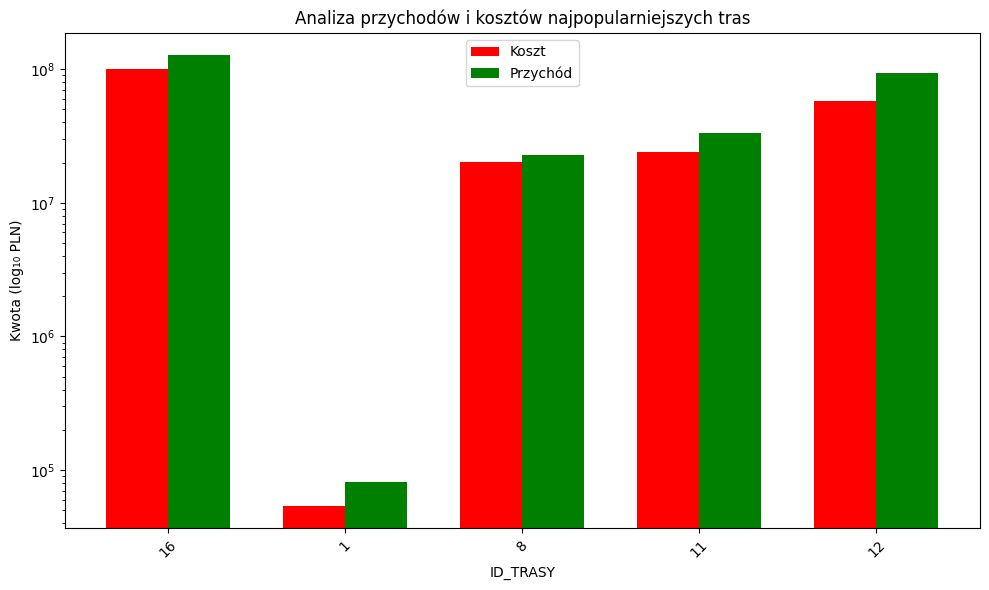

### Rekomendacje:

# 2. Liczba klientów w czasie, analiza trendu

W analizie skupiliśmy się na zmianach liczby obsłużonych klientów w czasie, uwzględniając dane z podziałem na miesiące. Dane odzwierciedlają aktywność klientów oraz potencjalne wahania popytu na usługi. Analiza pozwala na zidentyfikowanie ogólnego trendu, sezonowości oraz ewentualnych anomalii, co może stanowić podstawę do planowania działań marketingowych i operacyjnych.

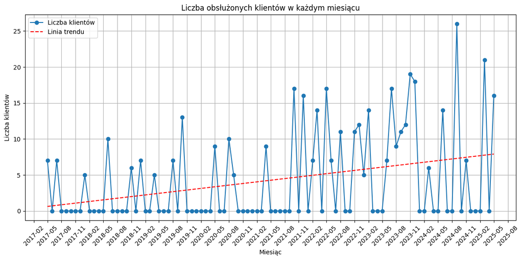

Liczba klientów w analizowanym okresie wykazuje trend rosnący, co zostało potwierdzone linią trendu (czerwona przerywana linia). Mimo zauważalnych wahań miesięcznych, ogólna liczba klientów systematycznie się zwiększa. Szczególnie od roku 2021 widoczne są coraz częstsze i wyższe piki zainteresowania.

### Wnioski

- Wykres sugeruje **dynamiczny rozwój firmy** i rosnące zainteresowanie usługami w ostatnich latach.
- Widoczne są **fluktuacje sezonowe** – spadki są częste, lecz krótkotrwałe.
- Trend długoterminowy jest **wyraźnie dodatni**.

### Rekomendacje

- **Utrzymać działania marketingowe**, które przyczyniły się do wzrostu w latach 2022–2024.
- **Zidentyfikować przyczyny okresowych spadków** i zaplanować promocje, które będą je równoważyć.
- Opracować **strategiczny kalendarz działań** oparty o analizę cykli popytu i zachowań klientów.

# 3. Po których wycieczkach klienci wracają, a po których już więcej ich nie widzimy?

W analizie skupiliśmy się na zachowaniach powracających klientów, badając, po których wycieczkach decydują się oni na ponowny udział w kolejnych podróżach. Celem było określenie, które trasy sprzyjają budowaniu lojalności, a które mogą zniechęcać klientów do dalszego korzystania z oferty. Identyfikacja tras o niskiej retencji może stanowić podstawę do rewizji oferty, dostosowania jakości usług lub całkowitego wycofania niektórych propozycji.

|  | ID_TRASY | STACJA_POCZATKOWA | STACJA_KONCOWA | PROCENT_NIE_WROCILO |
| --- | --- | --- | --- | --- |
| 1 | 2 | Orbitalna stacja Marsa | Orbitalna stacja Księżyca | 100.000000 |
| 3 | 5 | Orbitalna stacja Księżyca | Orbitalna stacja Europy | 100.000000 |
| 8 | 10 | Orbitalna stacja Marsa | Orbitalna stacja Europy | 100.000000 |
| 14 | 16 | Stacja przy powierzchni Ziemi | Orbitalna stacja Europy | 100.000000 |
| 13 | 15 | Stacja przy powierzchni Ziemi | Orbitalna stacja Księżyca | 92.307692 |
| 5 | 7 | Orbitalna stacja Marsa | Orbitalna stacja Jowisza | 91.428571 |
| 4 | 6 | Stacja przy powierzchni Ziemi | Orbitalna stacja Wenus | 89.285714 |
| 6 | 8 | Orbitalna stacja Marsa | Orbitalna stacja Merkurego | 87.878788 |
| 11 | 13 | Orbitalna stacja Marsa | Orbitalna stacja Wenus | 86.842105 |
| 2 | 4 | Stacja przy powierzchni Ziemi | Orbitalna stacja Marsa | 84.848485 |
| 9 | 11 | Orbitalna stacja Księżyca | Orbitalna stacja Marsa | 83.783784 |
| 15 | 17 | Stacja przy powierzchni Ziemi | Orbitalna stacja Merkurego | 83.333333 |
| 10 | 12 | Orbitalna stacja Księżyca | Orbitalna stacja Jowisza | 78.787879 |
| 12 | 14 | Orbitalna stacja Marsa | Stacja przy powierzchni Ziemi | 64.705882 |
| 0 | 1 | Orbitalna stacja Księżyca | Stacja przy powierzchni Ziemi | 61.538462 |
| 7 | 9 | Orbitalna stacja Księżyca | Orbitalna stacja Merkurego | 42.857143 |

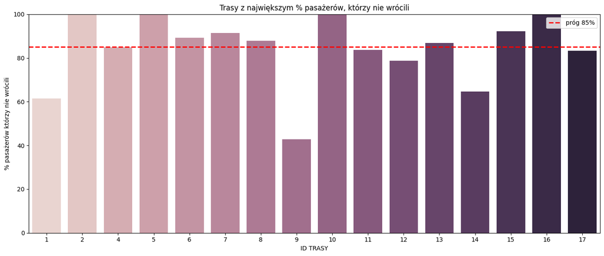

### Opis tras, po których klienci nie wracają:

- **2:** Orbitalna stacja Marsa → Orbitalna stacja Księżyca
- **5:** Orbitalna stacja Księżyca → Orbitalna stacja Europy
- **10:** Orbitalna stacja Marsa → Orbitalna stacja Europy
- **16:** Stacja przy powierzchni Ziemi → Orbitalna stacja Europy

### Opis tras, po których klienci najczęściej wracają:

- **9:** Orbitalna stacja Księżyca → Orbitalna stacja Merkurego
- **1:** Orbitalna stacja Księżyca → Stacja przy powierzchni Ziemi
- **14:** Orbitalna stacja Marsa → Stacja przy powierzchni Ziemi

### Wnioski:

- Duża liczba tras ma 100% wskaźnik niepowrotu klientów, co oznacza, że żaden z pasażerów nie skorzystał ponownie z usług po odbyciu konkretnej podróży. Dotyczy to tras o ID 2, 5, 10 oraz 16.
- Trasy kończące się na orbitalnej stacji Europy mają alarmująco wysoki wskaźnik rezygnacji — 100% klientów nie wraca po takiej podróży. Może to sugerować: niską atrakcyjność samego celu, niedogodności logistyczne, brak powrotów lub problemy operacyjne na tej trasie.
- Najlepszy wskaźnik powrotów odnotowano dla trasy: **Orbitalna stacja Księżyca → Orbitalna stacja Merkurego (ID 9)** - tylko 42,9% nie wróciło, co oznacza, że ponad połowa podróżnych była skłonna wrócić po tej trasie.

### Rekomendacje

- Rozważyć usunięcie z oferty tras o 100% wskaźniku niepowrotu klientów. Ich utrzymywanie generuje koszty, nie przekładając się na lojalność klientów.
- Przeprowadzić pogłębioną analizę tras o wysokim wskaźniku rezygnacji (np. >85%), obejmującą: opinie pasażerów, koszty i długość trwania, awaryjność i komfort podróży.
- Ulepszyć obsługę lub warunki podróży na krytycznych trasach, jeśli ich wycofanie nie jest możliwe (np. z powodów logistycznych lub strategicznych).

# 4. Pytania dodatkowe

## 4.1. Stosunek liczby klientów do czasu trwania wycieczki

W analizie skupiliśmy się na relacji między liczbą klientów a czasem trwania wycieczek. Celem było sprawdzenie, czy długość podróży ma wpływ na zainteresowanie klientów. Zestawiając dane dotyczące liczby uczestników z długością trwania poszczególnych wyjazdów, możliwe było zaobserwowanie potencjalnych zależności, które mogą wspierać decyzje dotyczące planowania oferty oraz optymalizacji tras.

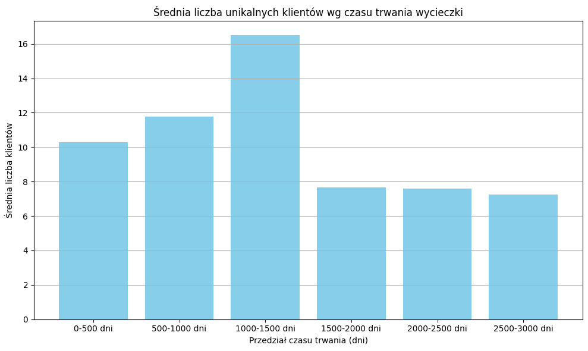

### Wnioski

- Największe zainteresowanie wycieczkami występuje w przedziale **1000–1500 dni**, gdzie średnia liczba klientów jest najwyższa i przekracza **16 osób**.
- Widzoczny jest wyraźny **spadek liczby klientów** dla wycieczek trwających **powyżej 1500 dni** – dłuższe podróże przyciągają mniejszą liczbę uczestników.
- Krótsze wycieczki (0–500 dni oraz 500–1000 dni) również cieszą się stosunkowo dobrą popularnością, ale nie osiągają wyników zbliżonych do maksimum.

### Rekomendacje

- **Optymalizować ofertę wokół przedziału 1000–1500 dni**, gdyż to w tym czasie podróże przyciągają najwięcej klientów.
- **Rozważyć ograniczenie liczby wycieczek trwających powyżej 1500 dni** lub dostosowanie ich formuły (np. podział na etapy, opcje krótsze) ze względu na niższe zainteresowanie.
- **Zintensyfikować promocje krótszych wyjazdów** (do 1000 dni), które nadal mają spory potencjał, szczególnie dla mniej zaangażowanych lub nowych klientów.

## 4.2. Analiza najbardziej rentownych tras

W analizie skupiliśmy się na identyfikacji tras przynoszących największe zyski netto, biorąc pod uwagę łączny koszt organizacji podróży oraz uzyskane przychody od pasażerów. Zestawienie obejmuje zarówno liczbę odbytych podróży dla danej trasy, jak i wartość finansową operacji, co pozwala ocenić jej opłacalność. Celem analizy jest wskazanie tras najbardziej efektywnych ekonomicznie, które generują najwyższy zysk przy uwzględnieniu poniesionych kosztów.

```
TOP 5 NAJBARDZIEJ RENTOWNYCH TRAS (PROCENTOWO):
|    |   ID_TRASY |   LICZBA |      KOSZT  |    PRZYCHÓD  |       ZYSK  |   RENTOWNOŚĆ (%) |
|----|------------|----------|-------------|--------------|-------------|------------------|
| 10 |          7 |        3 | 53372720.20 | 140031379.75 | 86658659.55 |         162.365  |
| 11 |         13 |        3 | 16716276.97 |  43443200.21 | 26726923.24 |         159.886  |
|  4 |         14 |        1 |  7592447.95 |  14341290.61 |  6748842.66 |          88.8889 |
|  9 |         12 |        4 | 58142479.10 |  94066225.07 | 35923745.97 |          61.7857 |
| 12 |         17 |        2 |  3341141.57 |   5371349.14 |  2030207.57 |          60.7639 |
```

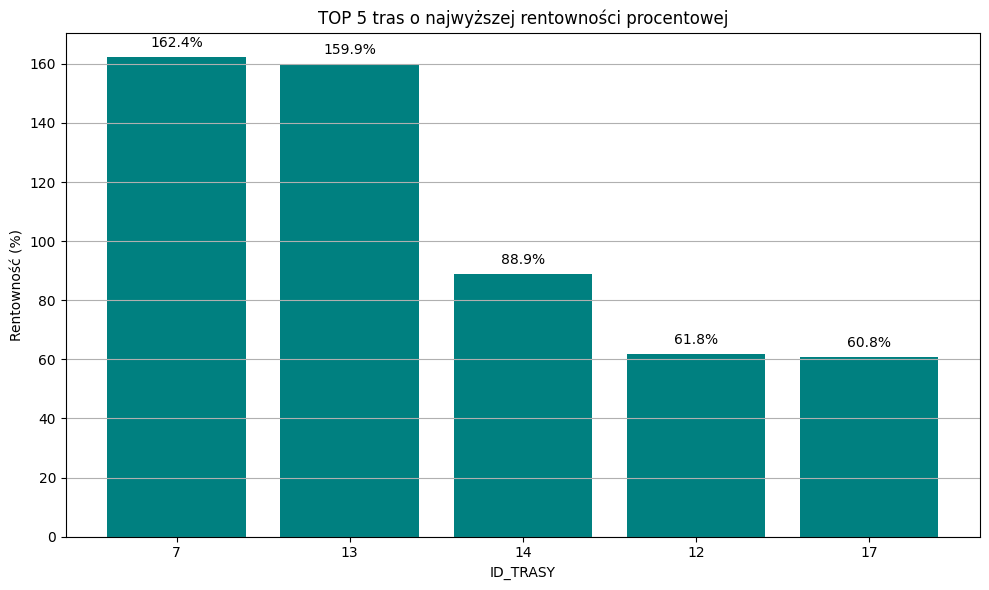

### Wnioski

- Najbardziej rentowną trasą jest **trasa nr 7**, która osiągnęła rentowność na poziomie **162,4%**, generując ponad 86 mln zysku przy trzech realizacjach.
- Na drugim miejscu znajduje się **trasa nr 13** z rentownością **159,9%**, również realizowana trzykrotnie, co pokazuje jej wysoką efektywność.
- **Trasa nr 14** uzyskała rentowność **88,9%** przy jednej realizacji – wskazuje to na duży potencjał przy ograniczonym wykorzystaniu.
- **Trasy 12 i 17** również osiągnęły dobre wyniki, przekraczając **60% rentowności**, co świadczy o ich opłacalności mimo większych kosztów (trasa 12) lub mniejszej skali (trasa 17).

## 4.3. Jakie typy pojazdów są najbardziej dochodowe?

Celem analizy było określenie, które typy pojazdów kosmicznych generują największy zysk. Wzięto pod uwagę nazwę producenta, model pojazdu oraz sumaryczny zysk, jaki pojazd wygenerował. Dane pozwalają zidentyfikować zarówno najefektywniejsze kombinacje (producent + model), jak i ocenić rentowność poszczególnych producentów lub konstrukcji.

|  | ID_POJAZDU | POJAZD | ZYSK |
| --- | --- | --- | --- |
| 0 | 1 | Rotary Rocket - Super Heavy (ID: 1) | 32457519.05 |
| 1 | 2 | Boeing - Atlas V (ID: 2) | 58753773.31 |
| 2 | 3 | Rotary Rocket - Falcon 9 (ID: 3) | 18791357.73 |
| 3 | 4 | Blue Origin - Atlas V (ID: 4) | 32724724.33 |
| 4 | 5 | Rotary Rocket - Falcon 9 (ID: 5) | 83287069.25 |
| 5 | 6 | Blue Origin - Super Heavy (ID: 6) | 49678203.91 |
| 6 | 7 | SpaceX - Antares (ID: 7) | 77003875.88 |
| 7 | 8 | Orbital ATK - Falcon 9 (ID: 8) | 7631271.60 |
| 8 | 9 | Rotary Rocket - Falcon 9 (ID: 9) | 26176534.27 |
| 9 | 10 | Blue Origin - Antares (ID: 10) | 20358204.50 |

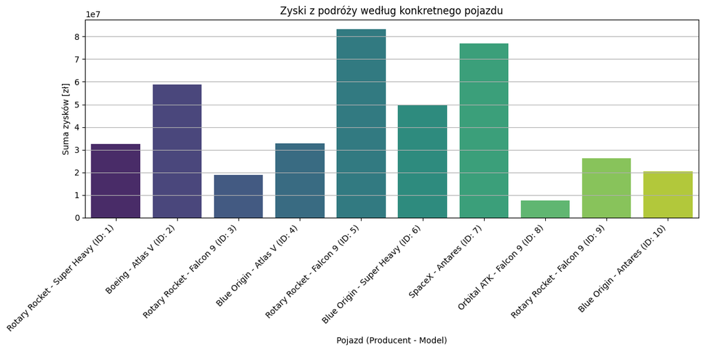

### Wnioski

- Najbardziej dochodowe pojazdy to:
  - Rotary Rocket - Falcon 9 (ID: 5) z zyskiem 83,287,069.25 PLN,
  - SpaceX - Antares (ID: 7) z zyskiem 77,003,875.88 PLN,
  - Boeing - Atlas V (ID: 2) z zyskiem 58,753,773.31 PLN.
- Model Falcon 9 pojawia się kilkukrotnie, w tym z różnymi producentami (Rotary Rocket, Orbital ATK), co sugeruje jego dużą popularność lub licencjonowanie. Dodatkowo, wersje produkowane przez Rotary Rocket osiągają znacznie wyższe zyski niż wersje pozostałych producentów.
- Najmniej dochodowy pojazd to Orbital ATK - Falcon 9 (ID: 8) z zyskiem 7,631,271.60, co może sugerować problemy z efektywnością, zainteresowaniem rynkowym lub większymi kosztami eksploatacji.

### Rekomendacje

- Rozważyć rozwój floty opartej na modelu Falcon 9, szczególnie tych wersji, które sprawdziły się w produkcji Rotary Rocket – dane pokazują ich wyjątkową rentowność.
- Kontynuować współpracę lub zwiększyć inwestycje w SpaceX i Blue Origin, których pojazdy również generują bardzo wysokie zyski.
- Przeanalizować przyczyny niskiej opłacalności pojazdu Orbital ATK - Falcon 9, mimo że to ten sam model jak inne bardziej dochodowe – problem może tkwić w zarządzaniu, trasach, wykorzystaniu lub wersji technicznej.

## 4.4. Które modele pojazdów są najbardziej eksploatowane i generują najwyższe koszty serwisowe?

Analiza dotyczy stopnia eksploatacji pojazdów oraz związanych z tym kosztów serwisowych. Wzięto pod uwagę cztery zmienne:

- SUMA_KM – łączna liczba kilometrów pokonana przez pojazd,
- LICZBA_PODROZY – liczba zrealizowanych misji,
- KOSZT_SERWISU – całkowity koszt serwisowania,
- KOSZT_SERWISU_NA_1000_KM – jednostkowy koszt serwisu przypadający na 1000 km.

Wyniki przedstawiono na radarowym wykresie porównującym modele pojazdów (model + producent).

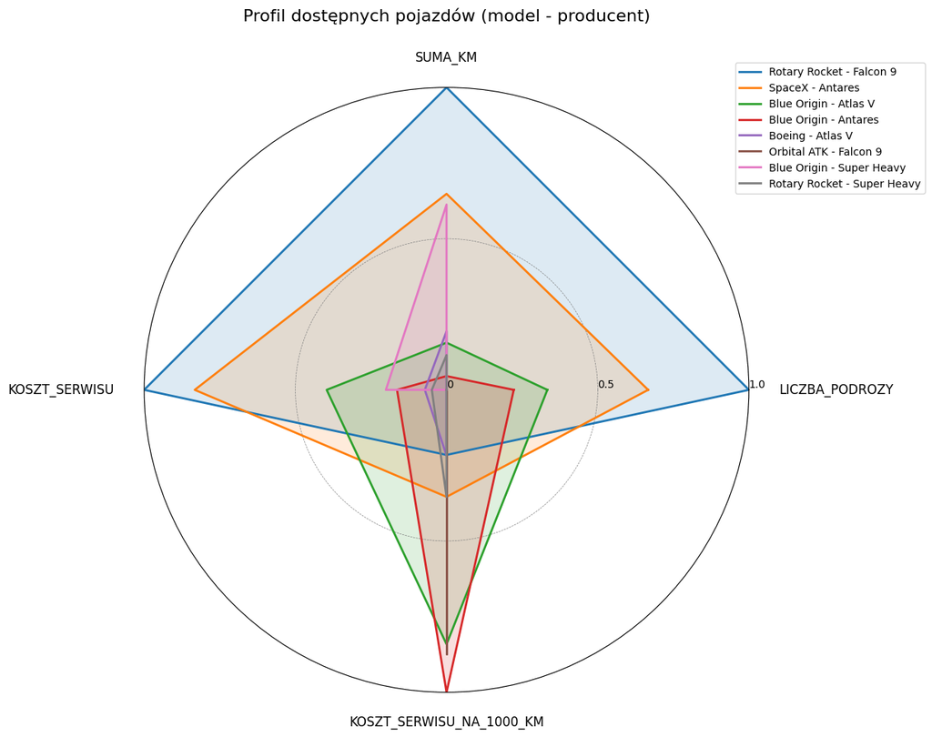

### Wnioski

- Najbardziej eksploatowany pojazd to Rotary Rocket - Falcon 9, który osiągnął najwyższe wartości zarówno pod względem liczby podróży, jak i pokonanych kilometrów. Jednocześnie generuje najwyższy całkowity koszt serwisu, choć koszt na 1000 km jest relatywnie niski.
- SpaceX - Antares również wypada wysoko pod względem eksploatacji i kosztów serwisowych. Choć jego całkowity koszt serwisu jest niższy niż lidera, to w przeliczeniu na 1000 km wypada mniej korzystnie – sugeruje to niższą efektywność kosztową na jednostkę dystansu.
- Pojazdy Blue Origin - Atlas V i Orbital ATK - Falcon 9 wykazują bardzo wysokie jednostkowe koszty serwisowania na 1000 km, mimo umiarkowanej lub niskiej eksploatacji – może to sugerować techniczne niedoskonałości lub nieopłacalność operacyjną.

### Rekomendacje

- Utrzymać i rozwijać flotę opartą na modelu Falcon 9 od Rotary Rocket, który – mimo wysokich kosztów – zapewnia efektywną eksploatację przy akceptowalnym koszcie jednostkowym.
- Monitorować pojazdy o wysokim koszcie serwisu na 1000 km, jak Blue Origin - Atlas V, aby ocenić, czy dalsze ich wykorzystywanie ma ekonomiczne uzasadnienie.